# Pulling oral and IV data from CvTdb

Caroline Ring

2023-05-10

Load necessary package

```r
library(DBI)
library(data.table)
library(ggplot2)
```

For connection to CvTdb:

Connect to EPA VPN.

Set environment variables for the user name, password, host, and dbname that will be used to connect. In Windows 10, go to the search bar in the menu and type “environment variables.” A menu item should pop up that says “Edit the system environment variables.” Click it. A window should pop up. On tab “Advanced” (where you should be already), there is a button “Environment Variables” in the lower right. Click it. Under “User variables for [YOURNAME]”, the top window, click the “New” button. Add a variable and value and click “OK”. Repeat clicking the “New” button and adding variables.

Doing it this way allows me to not hardcode the password.

# Connect to database

Open a PostGreSQL connection.

```r
 con <-  dbConnect(RPostgreSQL::PostgreSQL(),
            user = Sys.getenv("cvt_user"),
            password = Sys.getenv("cvt_password"), #
            host = Sys.getenv("cvt_host"), #
            dbname = Sys.getenv("cvt_dbname"))
```

# View the available tables

```r
dbGetQuery(con, "SELECT * FROM pg_catalog.pg_tables WHERE schemaname != 'pg_catalog' AND schemaname != 'information_schema'")
```

```
##    schemaname                     tablename tableowner tablespace hasindexes
## 1         cvt              conc_time_values  app_cvtdb       <NA>       TRUE
## 2      public     administration_route_dict    app_dba       <NA>      FALSE
## 3         cvt                     documents  app_cvtdb       <NA>       TRUE
## 4         cvt                       studies  app_cvtdb       <NA>       TRUE
## 5         cvt                 tk_parameters  app_cvtdb       <NA>       TRUE
## 6         cvt                        series  app_cvtdb       <NA>       TRUE
## 7         cvt                      subjects  app_cvtdb       <NA>       TRUE
## 8         cvt              conc_medium_dict  app_cvtdb       <NA>       TRUE
## 9      public                 cvt.chemicals    app_dba       <NA>      FALSE
## 10     public          cvt.conc_medium_dict    app_dba       <NA>      FALSE
## 11        cvt          tk_parameters_series  app_cvtdb       <NA>       TRUE
## 12        cvt         tk_parameters_studies  app_cvtdb       <NA>       TRUE
## 13        cvt     administration_route_dict  app_cvtdb       <NA>       TRUE
## 14        cvt                     chemicals  app_cvtdb       <NA>       TRUE
```

[output cut: 23 more lines]

I don’t fully know what all of this SQL query means, but it filters out various “internal” tables that are not actually part of CvTdb, and shows only the tables that are.

# Formulate a query

In PostGreSQL, you have to refer to tables as “[schema].[table]”. Note that in the table above, the schema for CvT tables is always “cvt.”

I don’t fully understand schemas yet.

I don’t have a full data dictionary so I don’t yet know how to filter correctly. The most expedient way to do it for me is to pull down each table separately, then filter and merge using e.g. data.table.

Here’s how to pull down each table separately.

```r
fpath <- "C:/Users/cring/OneDrive - Environmental Protection Agency (EPA)/CvTdb/"
this_date <- format(Sys.time(), "%Y_%m_%d")

#list of table names to pull down
tables <- c("conc_time_values",
            "series",
            "subjects",
            "studies",
            "chemicals",
            "documents")

#loop over table names and pull down each one
for (this_table in tables){
  print(this_table)
  this_query <- paste("SELECT * FROM",
                      paste0("cvt.", this_table))
  this_item <- dbGetQuery(con, this_query)
  this_item <- as.data.table(this_item)
  assign(this_table, this_item)

  #prepend table name to all variable names in each table
  #some variable names are repeated in multiple tables
  #this will let me keep track
  these_names <- names(eval(parse(text = this_table)))
  setnames(eval(parse(text = this_table)),
           these_names,
           paste(this_table,
                 these_names,
                 sep = "."))
}
```

```
## [1] "conc_time_values"
## [1] "series"
## [1] "subjects"
## [1] "studies"
## [1] "chemicals"
## [1] "documents"
```

Disconnect from database

```r
dbDisconnect(con)
```

```
## [1] TRUE
```

Now there are a bunch of `data.table` variables in the environment, one for each CvT table. They are `conc_time_values`, `series`, `studies`, `subjects`, `chemicals`, and `documents`.

# Merge

Merge conc_time_values with series

```r
tmp1 <- series[conc_time_values,
                         on = c("series.id" = "conc_time_values.fk_series_id"),
                         nomatch = NA]
```

Merge with studies

```r
tmp2 <- studies[tmp1,
               on = c("studies.id" = "series.fk_study_id"),
               nomatch = NA]
```

Merge in subjects info

```r
tmp3 <- subjects[tmp2, on = c("subjects.id" = "series.fk_subject_id"), nomatch = NA]
```

Merge in chemical info. There are two chemical ID foreign keys.

`series.fk_test_chemical_id` = chemical that was dosed

`series.fk_analyzed_chemical_id` = chemical that was measured in body media (tissue, blood/plasma, urine, etc.) May be the same as dosed chemical, but may be different if, for example, a metabolite was measured instead of the parent chemical.

To keep track of this, let me create two copies of the `chemicals` table – one called `chemicals_dosed` and one called `chemicals_analyzed`. That way I can get the DTXSID, CASRN, and preferred names for each one.

```r
chemicals_dosed <- copy(chemicals)
chemicals_analyzed <- copy(chemicals)
```

Change the variable-name prefixes from “chemicals.[var]” to “chemicals_dosed.[var]” and “chemicals_analyzed.[var]” .

```r
setnames(chemicals_dosed,
         names(chemicals_dosed),
         gsub(x = names(chemicals_dosed),
              pattern = "chemicals.",
              replacement = "chemicals_dosed.",
              fixed = TRUE))

setnames(chemicals_analyzed,
         names(chemicals_analyzed),
         gsub(x = names(chemicals_analyzed),
              pattern = "chemicals.",
              replacement = "chemicals_analyzed.",
              fixed = TRUE))
```

Now merge

```r
tmp4 <- chemicals_dosed[tmp3,
                        on = c("chemicals_dosed.id" = "series.fk_test_chemical_id"),
                        nomatch = NA]
tmp5 <- chemicals_analyzed[tmp4,
                           on = c("chemicals_analyzed.id" = "series.fk_analyzed_chemical_id"),
                           nomatch = NA]
```

Merge in documents info.

There are both extraction documents and reference documents_reference. Make two copies of documents – one for each.

```r
documents_reference <- copy(documents)
documents_extraction <- copy(documents)

setnames(documents_reference,
         names(documents_reference),
         gsub(x = names(documents_reference),
              pattern = "documents.",
              replacement = "documents_reference.",
              fixed = TRUE))

setnames(documents_extraction,
         names(documents_extraction),
         gsub(x = names(documents_extraction),
              pattern = "documents.",
              replacement = "documents_extraction.",
              fixed = TRUE))
```

```r
tmp6 <- documents_extraction[tmp5,
                  on = c("documents_extraction.id" ="studies.fk_extraction_document_id"),
                  nomatch = NA]
tmp7 <- documents_reference[tmp6,
                  on = c("documents_reference.id" ="studies.fk_reference_document_id"),
                  nomatch = NA]
```

I think this should do it.

```r
cvt_data <- copy(tmp7)
rm(tmp1, tmp2, tmp3, tmp4, tmp5, tmp6, tmp7)
```

# Exploring the data

How many series per study?

```r
n_series_per_study <- cvt_data[,
                               .(n_series = length(unique(series.id))),
                               by = studies.id]
n_series_per_study[, range(n_series)]
```

```
## [1]   1 420
```

# Look at one weird case

DTXSID1034187 had a weird situation where concentrations seemed very low for the “300” dose group. Let’s see what is going on there

```r
tmp <- cvt_data[chemicals_analyzed.dsstox_substance_id %in% "DTXSID1034187" &
                  studies.administration_route_normalized %in% c("oral", "iv") &
                  series.conc_medium_normalized %in% c("blood", "plasma")]
```

This should have reference IDs 141 and 142 – does it?

```r
tmp[, unique(documents_extraction.id)]
```

```
## [1] 141 142
```

OK good, so this is the data we were expecting.

This is tamoxifen. Though it does not have much document info, I traced it to https://doi.org/10.22427/NTP-DATA-DTXSID8021301

(the only curated document info avalable is this:)

```r
unique(tmp[, .(documents_extraction.url, documents_extraction.other_study_identifier)])
```

```
##                                                        documents_extraction.url
## 1: ftp://anonftp.niehs.nih.gov/ntp-cebs/datatype/NTP_TK/Individual_Animal_Data/
## 2: ftp://anonftp.niehs.nih.gov/ntp-cebs/datatype/NTP_TK/Individual_Animal_Data/
##    documents_extraction.other_study_identifier
## 1:                                       S0916
## 2:                                       S0917
```

That URL is now broken. But if I google “ntp S0916” I get the page at https://doi.org/10.22427/NTP-DATA-DTXSID8021301.

Though items are marked below LOD or below LOQ, the original data does not include what the LOD/LOQ actually were. I cannot find a written report with more information anywhere.

The original data does note the dose units as ug/mL and notes that 5 mL/kg were administered, and contains the initial body weight of each subject.

In fact I think these doses have *not* been correctly normalized. There should be values for `studies.dose_volume` and there are not

```r
tmp[, unique(studies.dose_volume)]
```

```
## [1] NA
```

```r
unique(tmp[, .(studies.dose_level_original, studies.dose_level_original_units, studies.dose_level_normalized, studies.dose_volume)])
```

```
##    studies.dose_level_original studies.dose_level_original_units
## 1:                         300                             mg/kg
## 2:                         300                             ug/mL
## 3:                         0.3                             mg/kg
## 4:                         100                             ug/mL
##    studies.dose_level_normalized studies.dose_volume
## 1:                           300                <NA>
## 2:                           300                <NA>
## 3:                           0.3                <NA>
## 4:                           100                <NA>
```

This apepars to be the only document where that original units of ug/mL do not get changed for normalized dose level

```r
cvt_data[studies.dose_level_normalized == studies.dose_level_original &
           studies.dose_level_original_units %in% "ug/mL",
         unique(documents_extraction.id)]
```

```
## [1] 141
```

Also, there is lots and lots of below-LOD data from study S0917 oral gavage administration that is not included in CvTdb at all.

Incidentally, the one with 300 mg/kg as the original dose level also seems to be wrong. That is study S0916. Looking at the original NTP data, those units are really ug/mL.

Visualize what I mean

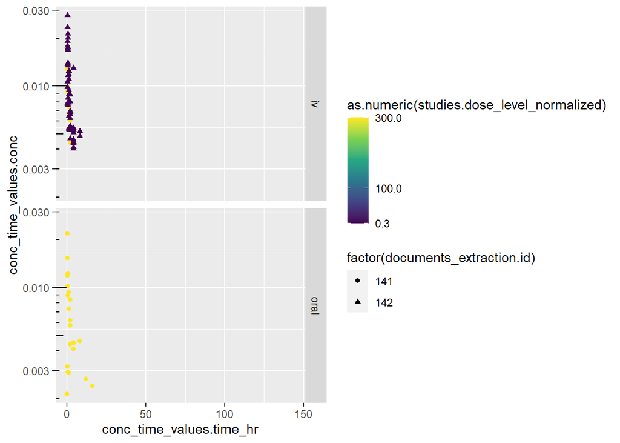

```r
ggplot(data = tmp) +
  geom_point(aes(x = conc_time_values.time_hr,
                 y = conc_time_values.conc,
                 shape = factor(documents_extraction.id),
                 color = as.numeric(studies.dose_level_normalized))) +
  facet_grid(rows = vars(studies.administration_route_normalized)) +
  scale_y_log10() +
  annotation_logticks(sides = "l") +
  scale_color_viridis_c(breaks = as.numeric(unique(tmp$studies.dose_level_normalized)))
```

Or plot dose-normalized

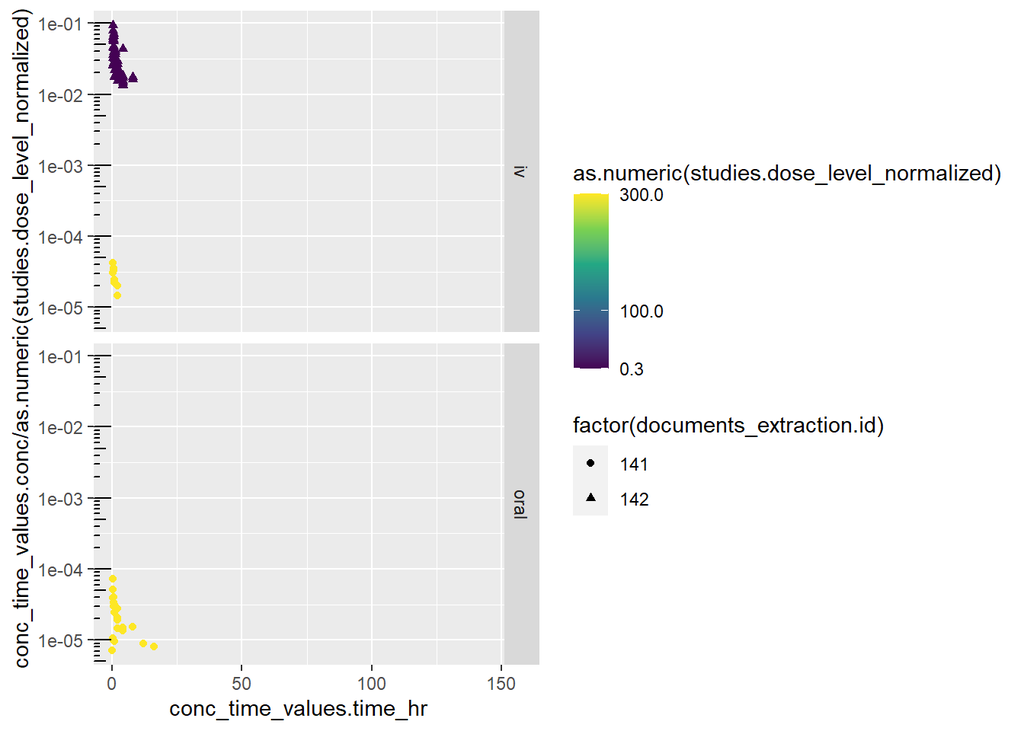

```r
ggplot(data = tmp) +
  geom_point(aes(x = conc_time_values.time_hr,
                 y = conc_time_values.conc/as.numeric(studies.dose_level_normalized),
                 shape = factor(documents_extraction.id),
                 color = as.numeric(studies.dose_level_normalized))) +
  facet_grid(rows = vars(studies.administration_route_normalized)) +
  scale_y_log10() +
  annotation_logticks(sides = "l") +
  scale_color_viridis_c(breaks = as.numeric(unique(tmp$studies.dose_level_normalized)))
```

We need to actually normalize the doses for these, properly. We will have to go to the original NTP data to do this, because the volumes of administration were not properly retained in CvTdb.

for study S0916, the oral gavage volume of administration was 5 mL/kg, and the IV volume of administration was 2 ml/kg.

```r
tmp[, studies.dose_level_normalized_corrected:=as.numeric(studies.dose_level_normalized)]

tmp[studies.dose_level_original_units %in% "ug/mL" &
      studies.administration_route_normalized %in% "oral",
    studies.dose_level_normalized_corrected:=as.numeric(studies.dose_level_original) * 5 * subjects.weight_kg/1000]

tmp[studies.dose_level_original_units %in% "ug/mL" &
      studies.administration_route_normalized %in% "iv",
    studies.dose_level_normalized_corrected:=as.numeric(studies.dose_level_original) * 2 * subjects.weight_kg/1000]

tmp[studies.dose_level_original_units %in% "mg/kg" &
      studies.dose_level_original %in% 300 &
      studies.administration_route_normalized %in% "iv",
    studies.dose_level_normalized_corrected:=as.numeric(studies.dose_level_original) * 2 * subjects.weight_kg/1000]
```

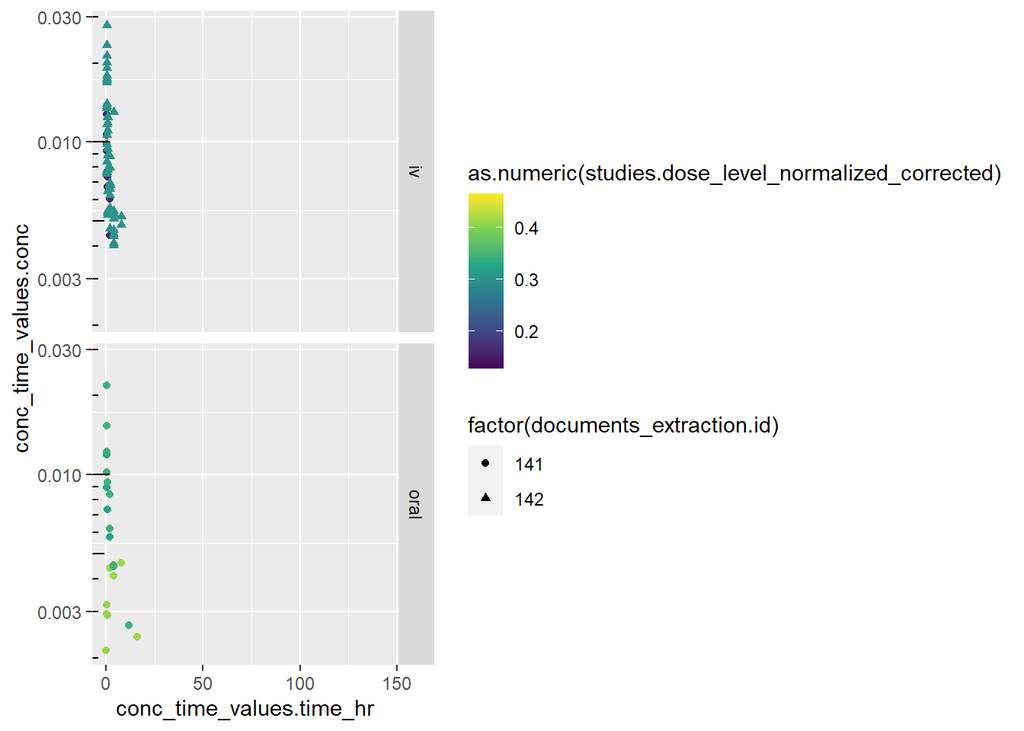

```r
ggplot(data = tmp) +
  geom_point(aes(x = conc_time_values.time_hr,
                 y = conc_time_values.conc,
                 shape = factor(documents_extraction.id),
                 color = as.numeric(studies.dose_level_normalized_corrected))) +
  facet_grid(rows = vars(studies.administration_route_normalized)) +
  scale_y_log10() +
  annotation_logticks(sides = "l") +
  scale_color_viridis_c()
```

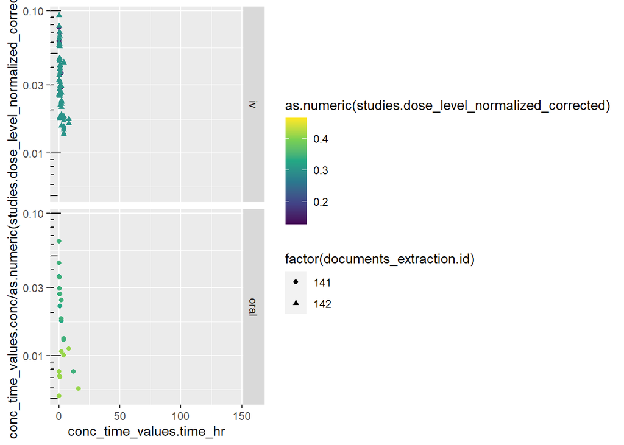

```r
ggplot(data = tmp) +
  geom_point(aes(x = conc_time_values.time_hr,
                 y = conc_time_values.conc/as.numeric(studies.dose_level_normalized_corrected),
                 shape = factor(documents_extraction.id),
                 color = as.numeric(studies.dose_level_normalized_corrected))) +
  facet_grid(rows = vars(studies.administration_route_normalized)) +
  scale_y_log10() +
  annotation_logticks(sides = "l") +
  scale_color_viridis_c()
```

Apply dose corrections to the full data table

```r
cvt_data[, studies.dose_level_normalized_corrected:=as.numeric(studies.dose_level_normalized)]

cvt_data[documents_extraction.id %in% 141 &
           studies.dose_level_original_units %in% "ug/mL" &
      studies.administration_route_normalized %in% "oral",
    studies.dose_level_normalized_corrected:=as.numeric(studies.dose_level_original) * 5 * subjects.weight_kg/1000]

cvt_data[documents_extraction.id %in% 141 &
      studies.dose_level_original_units %in% "ug/mL" &
      studies.administration_route_normalized %in% "iv",
    studies.dose_level_normalized_corrected:=as.numeric(studies.dose_level_original) * 2 * subjects.weight_kg/1000]

cvt_data[documents_extraction.id %in% 141 &
           studies.dose_level_original_units %in% "mg/kg" &
      studies.dose_level_original %in% 300 &
      studies.administration_route_normalized %in% "iv",
    studies.dose_level_normalized_corrected:=as.numeric(studies.dose_level_original) * 2 * subjects.weight_kg/1000]
```

## Correcting dose level units for PCB-126

Upon examining PCB-126, I think the original dose units should be ng/kg rather than mg/kg. If we look at https://cebs.niehs.nih.gov/cebs/study/002-02863-0008-0000-9 and look at the summary data rather than individual animal data, the dose units are listed as “ng/kg.” In the rest of the studies at https://cebs.niehs.nih.gov/cebs/test_article/57465-28-8 all of the dosing units are ng/kg. So I think that is what it should be.

```r
cvt_data[chemicals_dosed.dsstox_substance_id %in% "DTXSID3032179", studies.dose_level_original := "ng/kg"]
cvt_data[chemicals_dosed.dsstox_substance_id %in% "DTXSID3032179", studies.dose_level_normalized_corrected := as.numeric(studies.dose_level_normalized) * 1e-6] #convert to mg/kg
```

# Missing LOQs

```r
cvt_data[, n_obs_ref := sum(is.finite(conc_time_values.conc) & (conc_time_values.conc > 0) %in% TRUE),
         by = .(documents_extraction.id, documents_reference.id,
                chemicals_analyzed.dsstox_substance_id, chemicals_dosed.dsstox_substance_id,
                series.conc_medium_normalized, subjects.species)]

unique(cvt_data[n_obs_ref==0 &
                  series.conc_medium_normalized %in% c("blood", "plasma") &
                  studies.administration_route_normalized %in% c("oral", "iv"),
                  #chemicals_dosed.dsstox_substance_id == chemicals_analyzed.dsstox_substance_id,
                .(documents_extraction.id, documents_reference.id, documents_extraction.pmid, documents_extraction.doi, documents_extraction.other_study_identifier, chemicals_analyzed.dsstox_substance_id, chemicals_dosed.dsstox_substance_id, studies.test_substance_name_original, series.analyte_name_original, series.conc_medium_normalized, studies.administration_route_normalized)])
```

```
##     documents_extraction.id documents_reference.id documents_extraction.pmid
##  1:                      38                     NA                   6310077
##  2:                     132                     NA                        NA
##  3:                     132                     NA                        NA
##  4:                     133                     NA                        NA
##  5:                     133                     NA                        NA
##  6:                     134                     NA                        NA
##  7:                     134                     NA                        NA
##  8:                     136                     NA                        NA
##  9:                     136                     NA                        NA
## 10:                     136                     NA                        NA
## 11:                     141                     NA                        NA
## 12:                     141                     NA                        NA
## 13:                     141                     NA                        NA
## 14:                     142                     NA                        NA
```

[output cut: 75 more lines]

# Missing LOQ for documents_extraction.id 136

This is an NTP study. For some reason LOQs were not extracted. I looked up the original data and LOQs are noted. I will add them here. Source: https://cebs.niehs.nih.gov/cebs/test_article/58-08-2 click on “Individual Animal Data” to download spreadsheet. The LOQs are stated in comments like “XX is less than YYY, the ELOQ for [substance].”

```r
cvt_data[documents_extraction.id %in% 136 &
           series.analyte_name_original %in% "Caffeine",
         c("series.loq", "series.loq_units") := .(4.00, "ng/mL")]

cvt_data[documents_extraction.id %in% 136 &
           series.analyte_name_original %in% "L-Ephedrine",
         c("series.loq", "series.loq_units") := .(4.44, "ng/mL")]

cvt_data[documents_extraction.id %in% 136 &
           series.analyte_name_original %in% "Pseudoephedrine",
         c("series.loq", "series.loq_units") := .(4.43, "ng/mL")]
```

## Missing LOQ for documents_extraction.id 138

```r
cvt_data[documents_extraction.id %in% 138 &
           series.analyte_name_original %in% "Pentachloroanisole",
         c("series.loq", "series.loq_units") := .(0.05, "ug/mL")]
```

## Missing LOQ for documents_extraction.if 178

See https://ntp.niehs.nih.gov/publications/reports/tr/500s/tr526/index.html?utm_source=direct&utm_medium=prod&utm_campaign=ntpgolinks&utm_term=tr526abs Appendix F

LOQ in blood for rat was 30 pg/mL. (Individual animal data refers to plasma, but the PDF report refers to blood?)

```r
cvt_data[documents_extraction.id %in% 178 &
          series.analyte_name_original %in% "2,3,4,7,8-pentachlorodibenzofuran" &
           series.conc_medium_normalized %in% "plasma",
         c("series.loq", "series.loq_units") := .(30, "pg/mL")]
```

# Normalize LOQ units to mg/L

```r
cvt_data[, unique(series.loq_units)]
```

```
## [1] "ug/L"   NA       "ug/mL"  "nmol/L" "ug"     "ug/mL " "mg/L"   "ng/mL"
## [9] "pg/mL"
```

```r
cvt_data[, series.loq := as.numeric(series.loq)]
cvt_data[series.loq_units %in% "ug/L", series.loq_normalized := series.loq * 1e-3]
cvt_data[trimws(series.loq_units) %in% "ug/mL", series.loq_normalized := series.loq]
cvt_data[series.loq_units %in% "mg/L", series.loq_normalized := series.loq]
cvt_data[series.loq_units %in% "ng/mL", series.loq_normalized := series.loq * 1e-3]
cvt_data[series.loq_units %in% "pg/mL", series.loq_normalized := series.loq * 1e-6]
```

For that with nmol/L we will need the molecular weight. For items with units ug we would need the volume of media analyzed. Both of these are for inhalation data, though, which we aare not analyzing right now. So I will leave it alone for now.

# Concentration SD

These have not been normalized so we need to do it now.

```r
cvt_data[!is.na(conc_time_values.conc_sd_original), unique(series.conc_units_original)]
```

```
##  [1] "ug/L"          "ng/g tissue"   "uM"            "ug/kg"
##  [5] "ngEq/g"        "mg/kg"         "ug"            "ugEq/g tissue"
##  [9] "ug/mL"         "ppm"           "umol/L"        "mg"
## [13] "mg/L"          "ug/dL"         "umol/min"      "ug/g"
## [17] "ugEq/g"        "umol"
```

```r
cvt_data[series.conc_units_original == "ug/L",
         conc_time_values.conc_sd_normalized := conc_time_values.conc_sd_original * 1e-3]

cvt_data[series.conc_units_original == "ug/mL",
         conc_time_values.conc_sd_normalized := conc_time_values.conc_sd_original]

cvt_data[series.conc_units_original == "mg/L",
         conc_time_values.conc_sd_normalized := conc_time_values.conc_sd_original]

cvt_data[series.conc_units_original == "ug/dL",
         conc_time_values.conc_sd_normalized := conc_time_values.conc_sd_original * 1e-4]

cvt_data[series.conc_units_original == "ng/mL",
         conc_time_values.conc_sd_normalized := conc_time_values.conc_sd_original * 1e-3]

cvt_data[series.conc_units_original == "pg/mL",
         conc_time_values.conc_sd_normalized := conc_time_values.conc_sd_original * 1e-6]
```

We don’t have any cases for oral/IV in blood/plasma where concentration lower/upper bounds are given, so we won’t worry about normalizing these bounds right now.

```r
cvt_data[!is.na(conc_time_values.conc_upper_bound_original) & studies.administration_route_normalized %in% c("oral", "iv") & series.conc_medium_normalized %in% c("blood", "plasma")]
```

```
## Empty data.table (0 rows and 176 cols): documents_reference.id,documents_reference.pmid,documents_reference.doi,documents_reference.first_author,documents_reference.year,documents_reference.title...
```

To save space, filter CVT data to oral/IV routes and blood/plasma media, because nothing else is implemented right now. Also filter down to cases where administered and analyzed DTXSID are the same.

```r
cvt <- cvt_data[studies.administration_route_normalized %in% c("oral", "iv") &
                  series.conc_medium_normalized %in% c("blood", "plasma") &
                  chemicals_dosed.dsstox_substance_id == chemicals_analyzed.dsstox_substance_id]
```

```r
getwd()
```

```
## [1] "C:/Users/cring/invivoPKfit/invivopkfit/data-raw"
```

Filter out any variables that are all-NA.

```r
all_na <- cvt[, sapply(.SD, function(x) all(is.na(x)))]
na_vars <- names(all_na)[all_na %in% TRUE]
cvt[, (na_vars) := NULL]
```

Save the pulled CVT data with the edits/normalizations, and also save the current date.

```r
cvt_date <- Sys.Date()
save(cvt, file = "../data/cvt.rda", compress = "bzip2")
save(cvt_date, file = "../data/cvt_download_date.rda")
```